# Log-normal distribution

Ainesh Sewak

### Preliminaries

Let’s start by setting a seed so the charts are reproducible.

```r
set.seed(353)
```

Also we will be using `ggplot2` for any plotting. As such you need to first install the package (if you haven’t already done so). Type (within R) `install.packages("ggplot2")`

You then load the R/ggplot2 package using the `require` function:

```r
require(ggplot2)
```

### Log-normal distribution background

If a random variable $X$ is log-normally distributed then $\ln(X)$ has a normal distribution. ie.

If $X \sim \text{Lognormal}(\mu, \sigma)$ then $\ln(X) \sim \mathcal{N}(\mu, \sigma)$

The log-normal distribution has density given by

$f(x) = \frac{1}{\sqrt{2\pi}\sigma x} \text{exp}(\frac{-(\log(x) - \mu)^2}{2 \sigma^2})$

where $\mu$ and $\sigma$ are the mean and standard deviation of the logarithm.

The arithmetic mean and the arithmetic variance of a log-normally distributed variable $X$ is given by

${E(X) = \text{exp}(\mu + \frac{1}{2} \sigma^2)}{}$,

${Var(X) = \text{exp}(2\mu + \sigma^2)(\text{exp}(\sigma^2) - 1)}$

### Create a random sample

Next we can use the `rlnorm()` function to generate samples from a log-normal distribution $X \sim \text{Lognormal}(\mu = 1, \sigma = 0.25)$

```r
mu <- 1
sigma <- 0.25
x <- rlnorm(n = 100, meanlog = mu, sdlog = sigma)
```

The sample mean $\bar{X}$ is 2.6553099 and the sample variance $\ s^2$ is 0.3881367.

The theoretical mean of the distribution $X$ is 2.8045694 and the variance is 0.5072882.

### Histogram on a linear scale

We can use the `ggplot` function to generate a histogram for $X$.

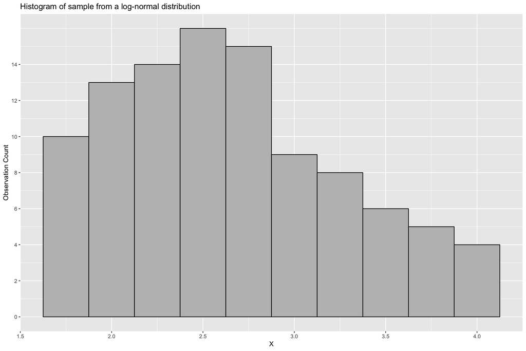

```r
ggplot(data = data.frame(x), aes(x)) +
  geom_histogram(binwidth = 0.25, fill = I("grey"), col = I("black")) +
  scale_y_continuous(breaks = seq(0,15,2)) +
  labs(title = "Histogram of sample from a log-normal distribution", x = "X", y = "Observation Count")
```

### Histogram on a log-scale

It is also interesting to take a look at our distribution on a log scale. This is because it should essentially look like a normal distribution on this scale.

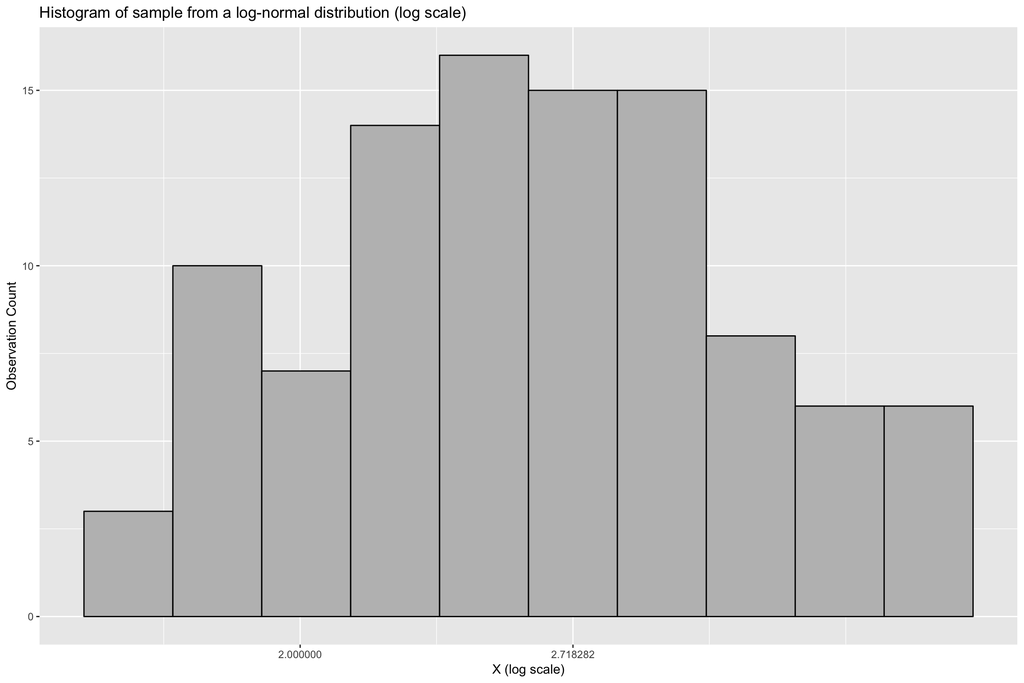

```r
ggplot(data = data.frame(x), aes(x)) +
  geom_histogram(binwidth = 0.1, fill = I("grey"), col = I("black")) +
  scale_x_continuous(trans='log') +
  labs(title = "Histogram of sample from a log-normal distribution (log scale)", x = "X (log scale)", y = "Observation Count")
```